# White Wine Quality Analysis by Min Lai

========================================================

I explored the white wine quality data set. Sequence number column in original dataset is removed since it is not very helpful.

```
## 'data.frame':    4898 obs. of  12 variables:
##  $ fixed.acidity       : num  7 6.3 8.1 7.2 7.2 8.1 6.2 7 6.3 8.1 ...
##  $ volatile.acidity    : num  0.27 0.3 0.28 0.23 0.23 0.28 0.32 0.27 0.3 0.22 ...
##  $ citric.acid         : num  0.36 0.34 0.4 0.32 0.32 0.4 0.16 0.36 0.34 0.43 ...
##  $ residual.sugar      : num  20.7 1.6 6.9 8.5 8.5 6.9 7 20.7 1.6 1.5 ...
##  $ chlorides           : num  0.045 0.049 0.05 0.058 0.058 0.05 0.045 0.045 0.049 0.044 ...
##  $ free.sulfur.dioxide : num  45 14 30 47 47 30 30 45 14 28 ...
##  $ total.sulfur.dioxide: num  170 132 97 186 186 97 136 170 132 129 ...
##  $ density             : num  1.001 0.994 0.995 0.996 0.996 ...
##  $ pH                  : num  3 3.3 3.26 3.19 3.19 3.26 3.18 3 3.3 3.22 ...
##  $ sulphates           : num  0.45 0.49 0.44 0.4 0.4 0.44 0.47 0.45 0.49 0.45 ...
##  $ alcohol             : num  8.8 9.5 10.1 9.9 9.9 10.1 9.6 8.8 9.5 11 ...
##  $ quality             : int  6 6 6 6 6 6 6 6 6 6 ...
```

```
##  [1] "fixed.acidity"        "volatile.acidity"     "citric.acid"
##  [4] "residual.sugar"       "chlorides"            "free.sulfur.dioxide"
##  [7] "total.sulfur.dioxide" "density"              "pH"
## [10] "sulphates"            "alcohol"              "quality"
```

```
##  fixed.acidity    volatile.acidity  citric.acid     residual.sugar
##  Min.   : 3.800   Min.   :0.0800   Min.   :0.0000   Min.   : 0.600
##  1st Qu.: 6.300   1st Qu.:0.2100   1st Qu.:0.2700   1st Qu.: 1.700
##  Median : 6.800   Median :0.2600   Median :0.3200   Median : 5.200
##  Mean   : 6.855   Mean   :0.2782   Mean   :0.3342   Mean   : 6.391
##  3rd Qu.: 7.300   3rd Qu.:0.3200   3rd Qu.:0.3900   3rd Qu.: 9.900
##  Max.   :14.200   Max.   :1.1000   Max.   :1.6600   Max.   :65.800
##    chlorides       free.sulfur.dioxide total.sulfur.dioxide
##  Min.   :0.00900   Min.   :  2.00      Min.   :  9.0
##  1st Qu.:0.03600   1st Qu.: 23.00      1st Qu.:108.0
##  Median :0.04300   Median : 34.00      Median :134.0
##  Mean   :0.04577   Mean   : 35.31      Mean   :138.4
##  3rd Qu.:0.05000   3rd Qu.: 46.00      3rd Qu.:167.0
##  Max.   :0.34600   Max.   :289.00      Max.   :440.0
##     density             pH          sulphates         alcohol
##  Min.   :0.9871   Min.   :2.720   Min.   :0.2200   Min.   : 8.00
##  1st Qu.:0.9917   1st Qu.:3.090   1st Qu.:0.4100   1st Qu.: 9.50
##  Median :0.9937   Median :3.180   Median :0.4700   Median :10.40
##  Mean   :0.9940   Mean   :3.188   Mean   :0.4898   Mean   :10.51
##  3rd Qu.:0.9961   3rd Qu.:3.280   3rd Qu.:0.5500   3rd Qu.:11.40
##  Max.   :1.0390   Max.   :3.820   Max.   :1.0800   Max.   :14.20
##     quality
##  Min.   :3.000
##  1st Qu.:5.000
##  Median :6.000
##  Mean   :5.878
##  3rd Qu.:6.000
##  Max.   :9.000
```

# Univariate Plots Section

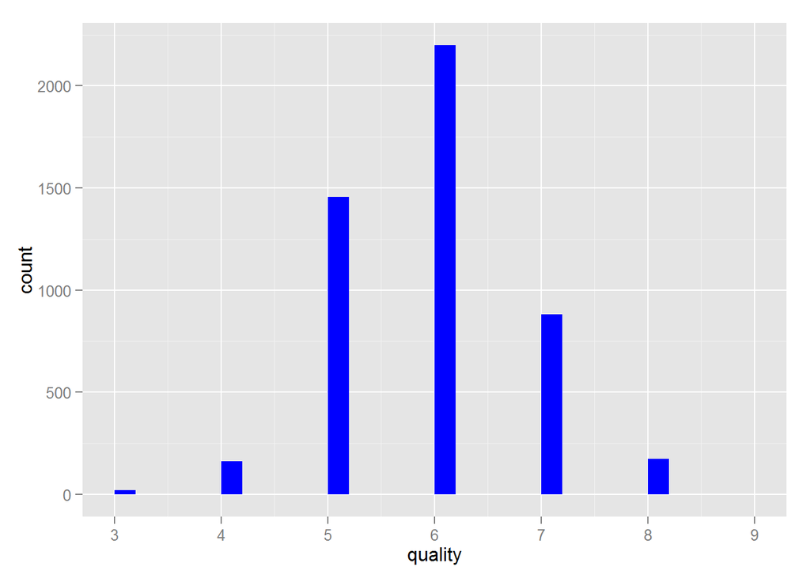

```
## $title
## [1] "Quality Distribution"
##
## attr(,"class")
## [1] "labels"
```

There are only 5 white wines sample has best quality((9) and 20 samples with worst quality(3). The best quality wines may be very rare and hard to find and worse ones may be due to production defect which also not very many. And the distribution close to normal distribution.

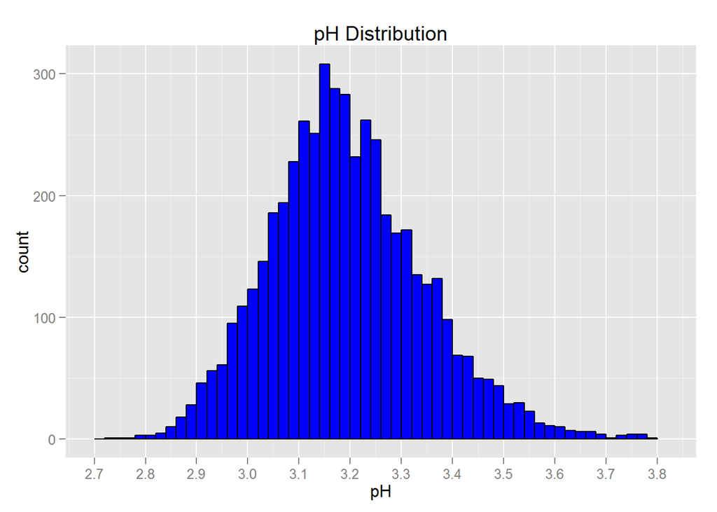

pH is normal distribution and there is a spike around pH 3.16-3.18

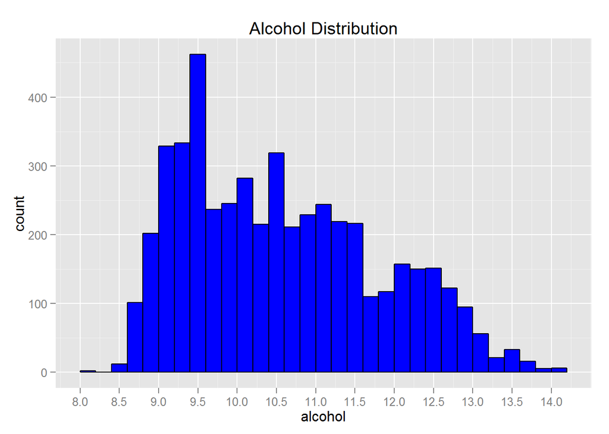

Alcohol is rarely over 14.0% and less than 8.5. Spike is at around 9.5%

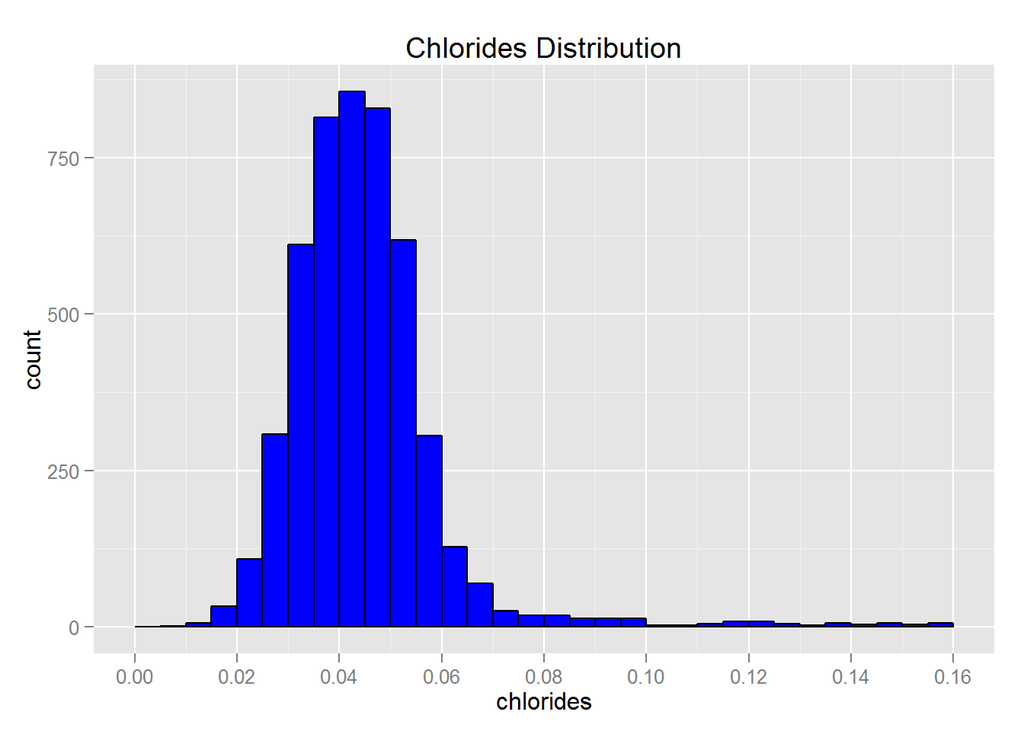

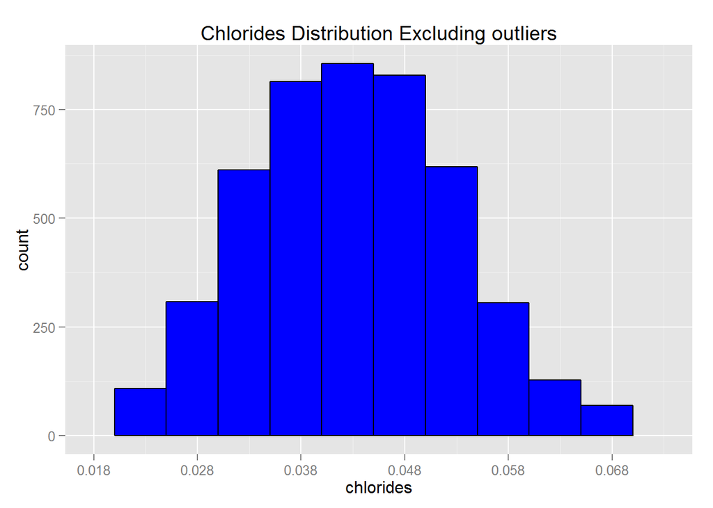

Chlorides is rarely over 0.06 and there is a spike around its median value. If more outliers are trimmed, it also looks like a normal distribution.

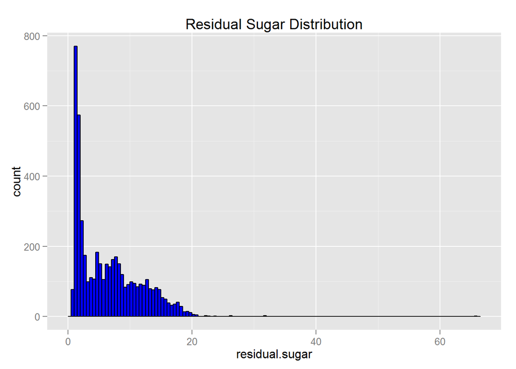

Residual sugar has two big spikes at 1-1.5 an 1.5 -2.0. It has a long tail on right side.

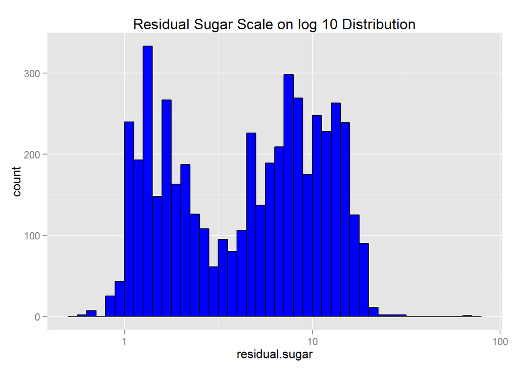

Transform scale to log 10 to see if the long tail can be removed. In log10, I saw bimodal distribution.

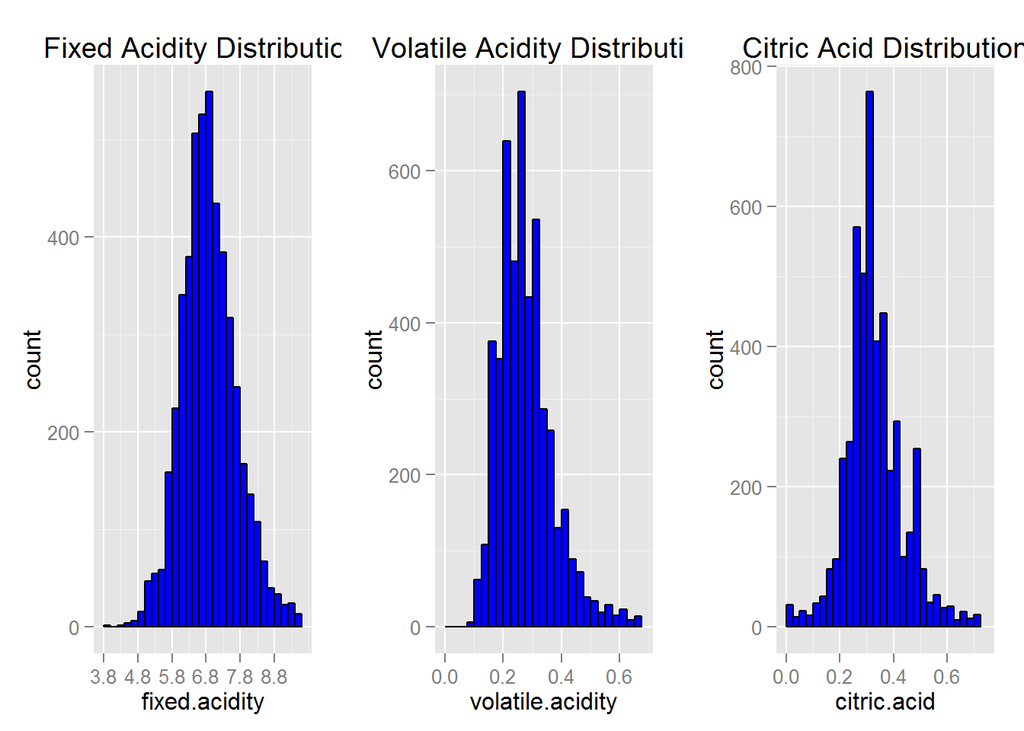

I grouped acidity related attributes together to compare their distributions. outliers are excluded in plots above. They have similar pattern which are all close to normal distribution especially fixed acidity distribution.

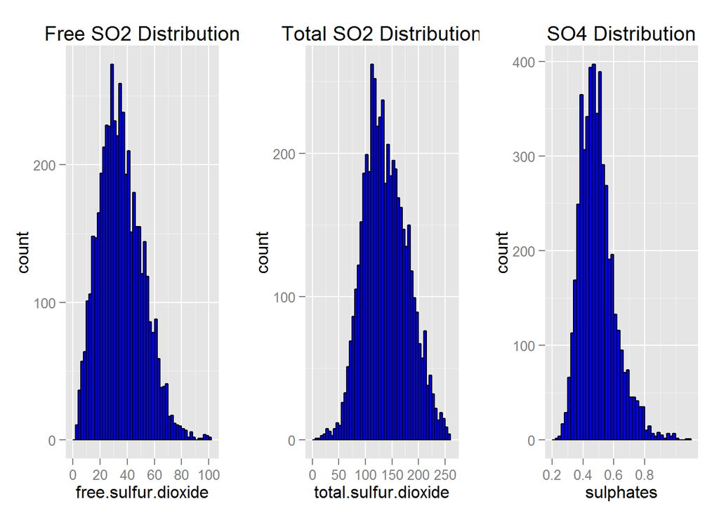

I grouped sulfur related attributes together to compare their distributions as well. outliers are excluded in plots above. The pattern also looks alike. All 3 have normal distribution with spike around their respect median value.

# Univariate Analysis

### What is the structure of your dataset?

There are 12 features in this dataset:Fixed.acidity, votatile.acidity, citric.acid, residual.sugar, chlorides, free.sulfur.dioxide, total.sulfur.dioxide, density, pH, sulphates, alcohol, quality. Except quality is integer, other feature are all numbers. For white wine quality ranging from 3 to 9, larger the number, better the quality. Best quality wines and worse quality wine are both very few. Median quality is 6 and there are 2198 wine samples in this quality which is 45% of whole dataset.

### What is/are the main feature(s) of interest in your dataset?

The main feature for this dataset is quality. I will explore relationships between quality and other features and try to find if wine quality can be predicated by its chemical attributes.

### What other features in the dataset do you think will help support your investigation into your feature(s) of interest?

Alcohol is number one feature need to be evaluated. Then pH, fixed.acidity(other acidity attributes), total.sulfur.dioxide(other sulfur attributes) and chlorides since they are all has close to normal distribution.

### Did you create any new variables from existing variables in the dataset?

No, not in this section. However I will create a new one to convert quality to factor type, so that I can use it as categorical feature in plotting.

### Of the features you investigated, were there any unusual distributions? Did you perform any operations on the data to tidy, adjust, or change the form of the data? If so, why did you do this?

# Bivariate Plots Section

### Scatter plot matrix

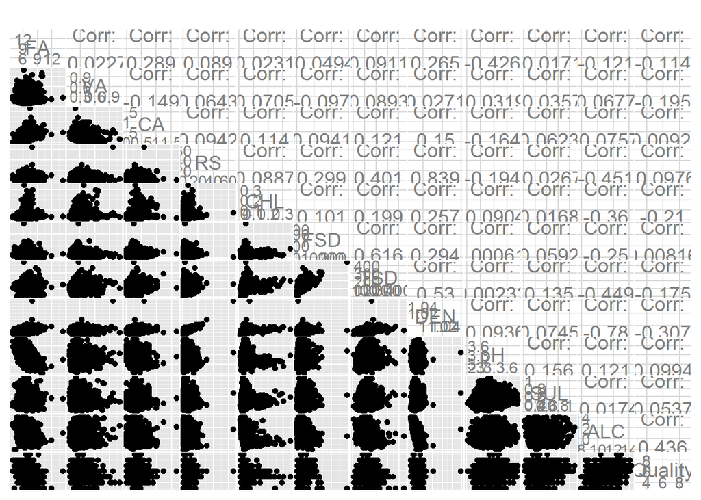

Legends for parameters in scatter plot matrix: FA - fixed.acidity vA - volatile acidity CA - Citric.acid, RS - residual.sugar CHL - chlorides FSD - free.sulfur.dioxide TSD - total.sulfur.dioxide, DEN - density pH - pH SUL - sulphates ALC - alcohol Quality - quality

Based the correction provided in scatter matrix, I looked into quality relationship with following features: alcohol, pH, chlorides, density, residual sugar, total sulfur dioxide, and volatile acidity, trying to find out which features have significant impact on quality.

Since there are only 5 wines with quality = 9 and 20 with quality = 3, there are only less than 1% of total number of wines in the dataset. They can be treated as outliers and excluded in some analysis like histogram by quality. There are to too few samples to generate histgram for wines has quality 3 or 9. So a subset whitewines_sub will be created excluding quality 3 and 9 wines

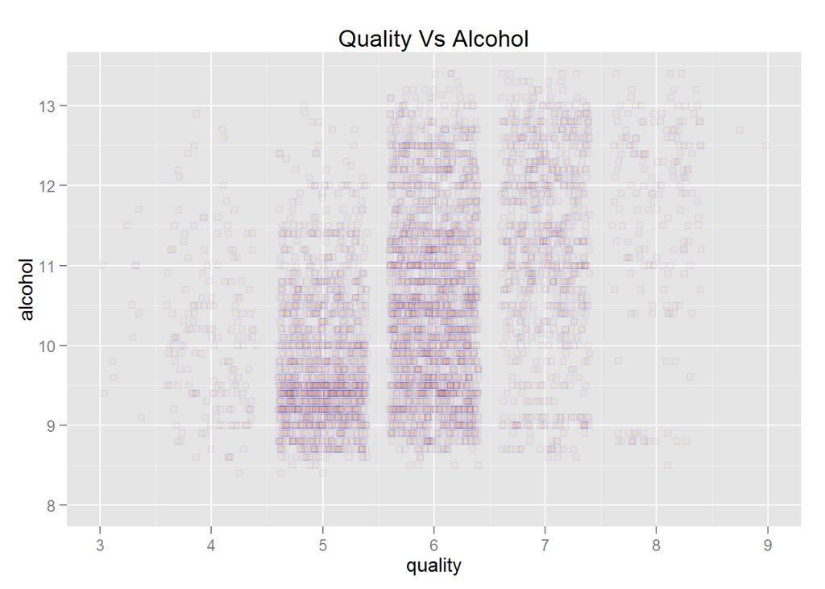

Scatter plot looks has over plotting issue even if alpha is set to 1/20. However, I can still see taht higher quality wines tend to have higher alcohol content except wine with quality = 3 and 4. Correlation between quality and alcohol content is 0.436.

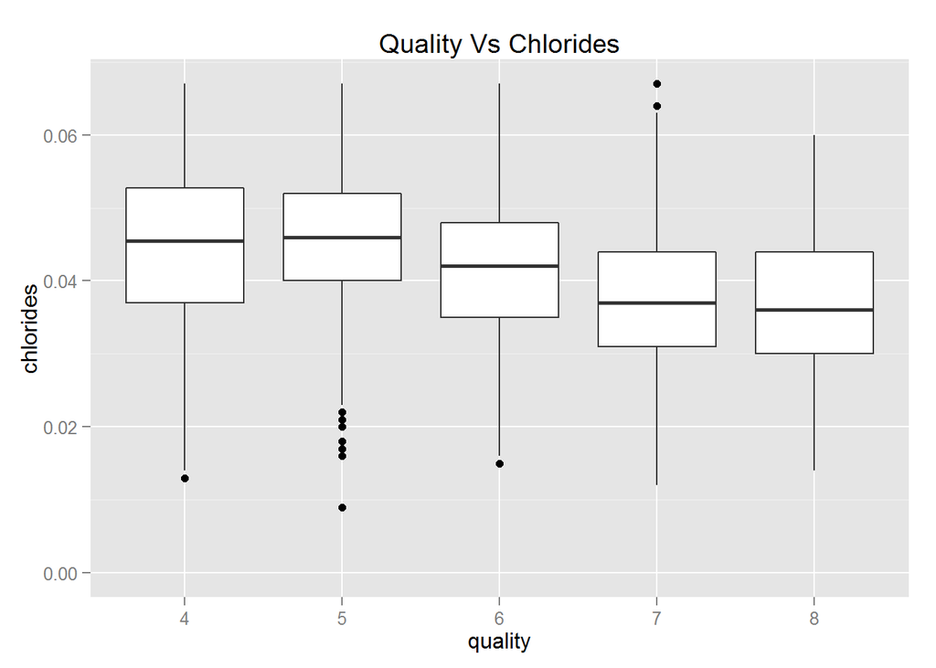

Quality decreases as chlorides increases, especially for wines with quality between 5 and 7. Correlation between quality and chlorides is -0.21.

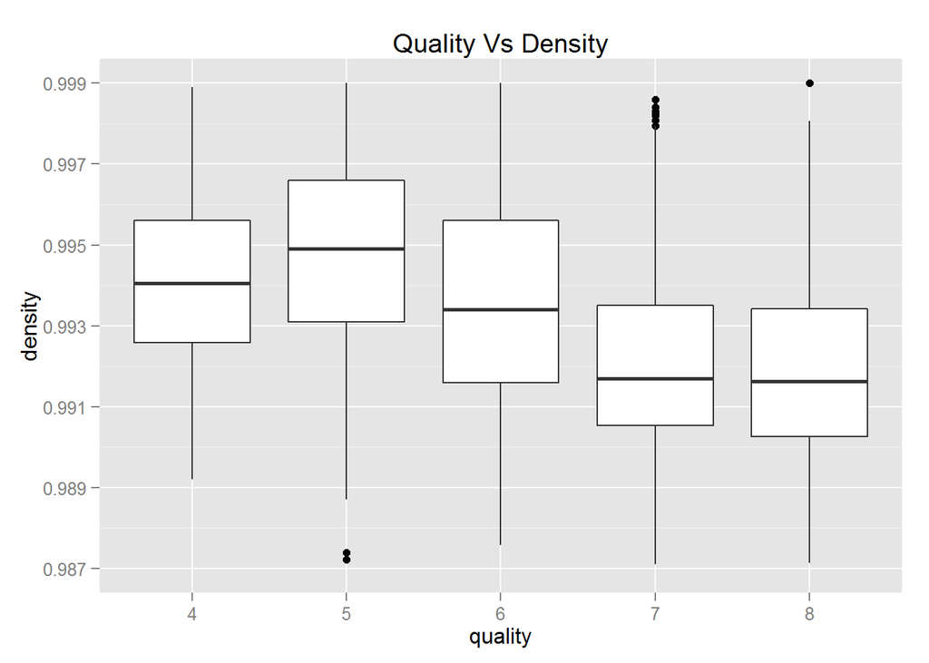

Quality decreases when density increases. Correlation between qualtiy and density is -0.307

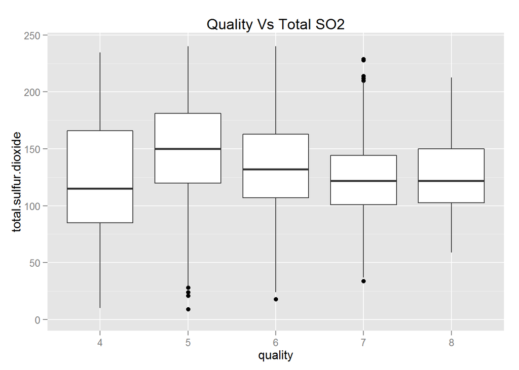

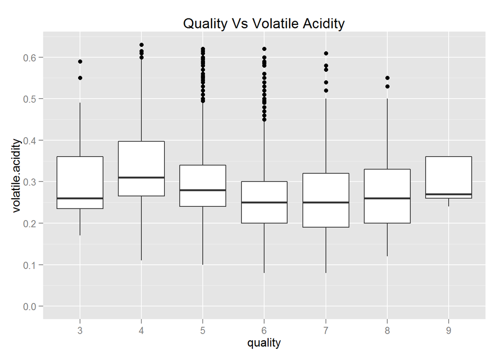

To my surprise, quality 6, 7, 8 has very close median volatile acidity. It is not very obvious that volatile acidity has much impact on wine quality. Correlation between quality and volatile acidity is -0.195

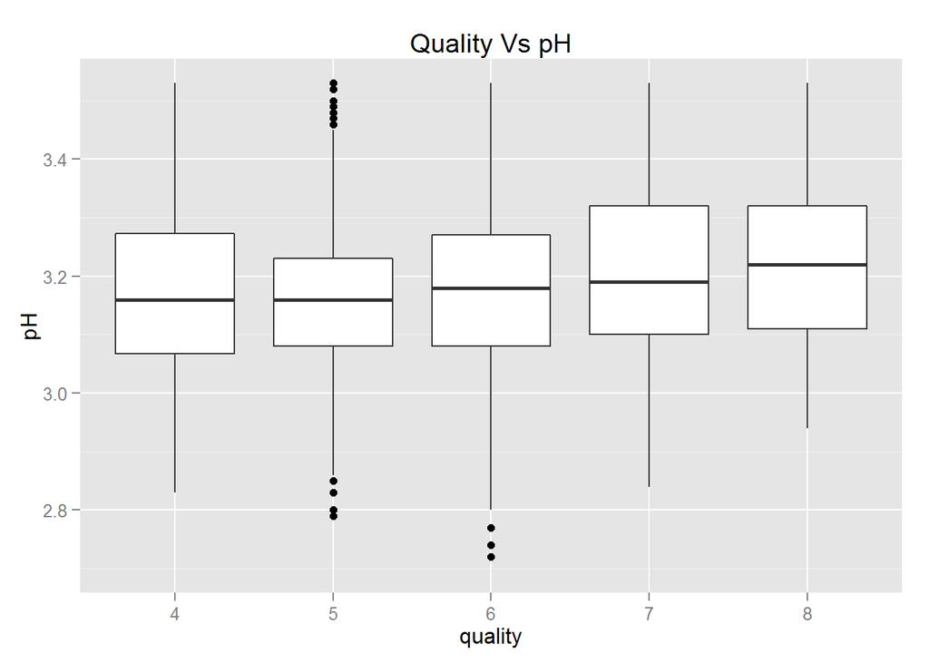

I can’t see much pH impact on quality of wines. So I would like to draw a histogram by quality to cross exam

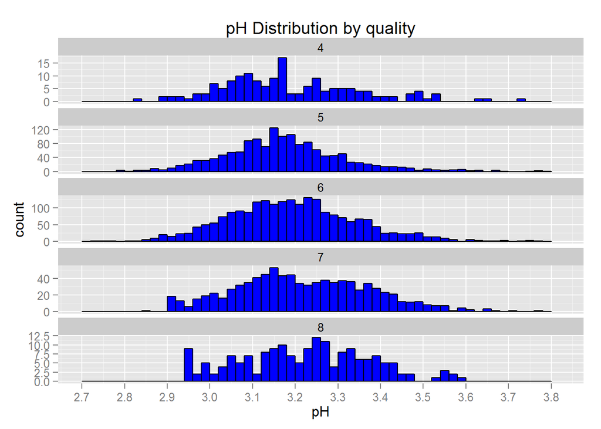

pH distribution for each wine quality is very close from quality 4-8. So pH looks like having very little impact on quality. Correlation between quality and pH is 0.0994.

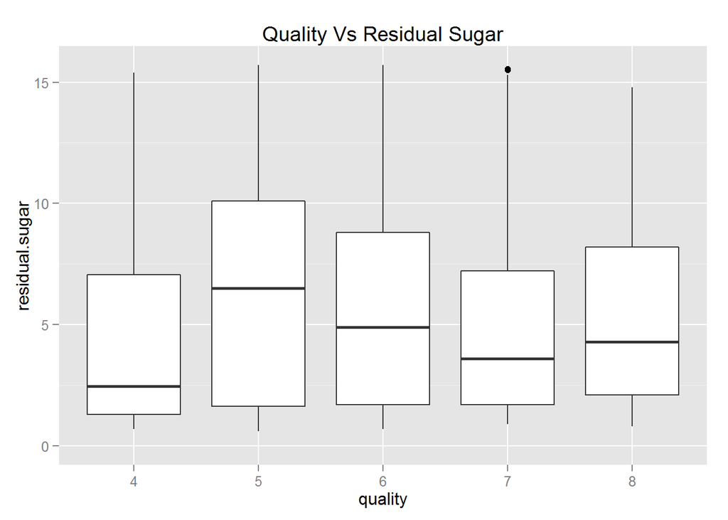

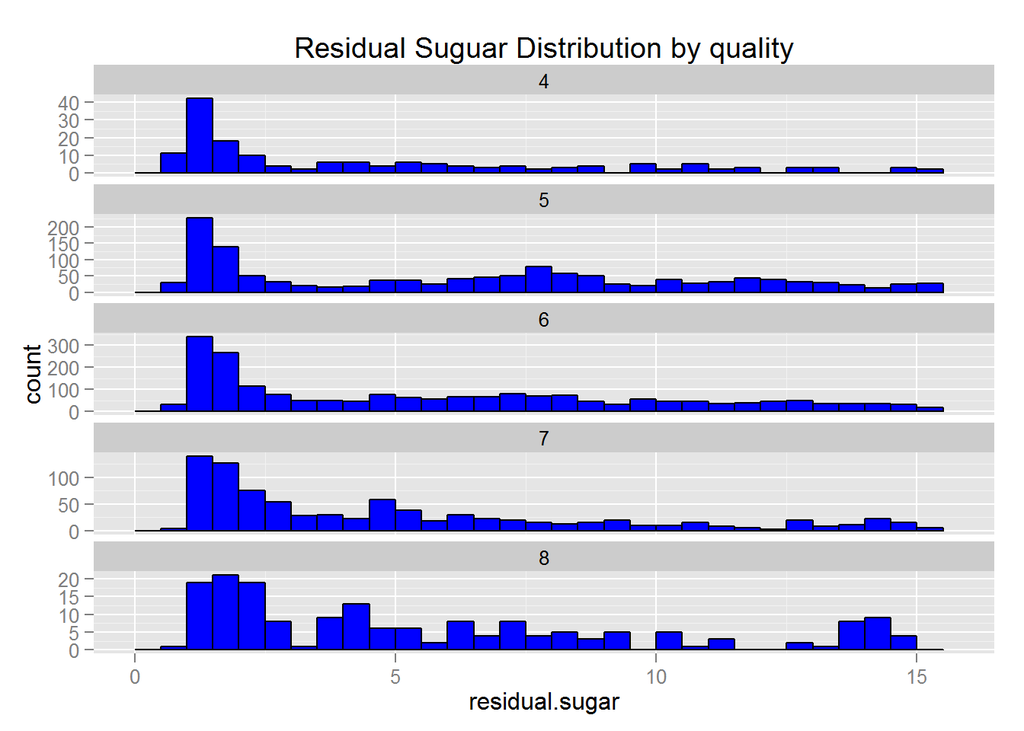

To my surprise, quality 4 wines has the lowest median residual sugar even lower than quality 8 wines. From quality between 5-7, the quality increase as residual sugar decreases. However, quality 8 wines has higher median residual sugar than quality 7 wines. So the correction between quality and residual sugar doesn’t look not very strong and their Correlation is only 0.0976

After exploring relationship between quality and 7 other major features, I continue to investigate the relationship between other feature pairs like density Vs alcohol, density Vs residual sugar, volatile acidity Vs fixed acidity ect.

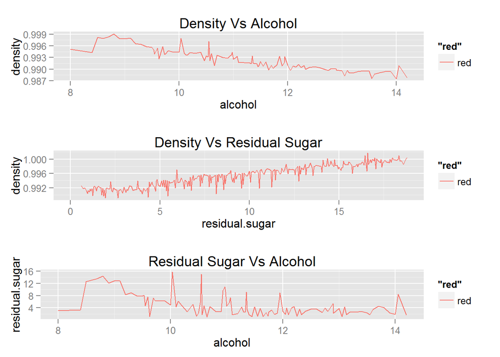

Density decreases when alcohol increases. Density increase when residual sugar increases. And although there are some spikes, overall, residual sugar decrease as alcohol increase. Here are their correlation density and alcohol: -0.78 density and residual sugar: 0.839 residual sugar and alcohol: -0.451

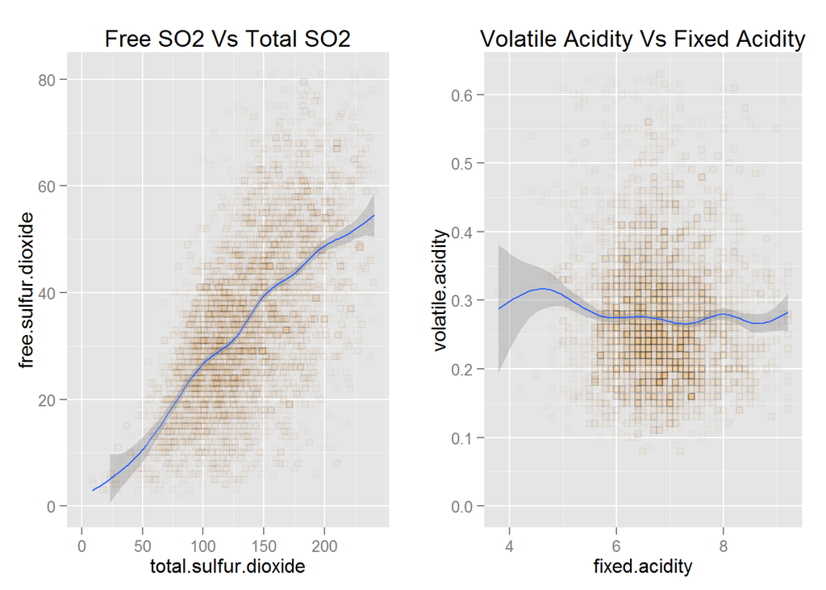

Free sulfur dioxide has strong positive correlation with total sulfur dioxide. On the other hand, Volatile acidity looks irrelevant to fixed acidity. Here are their correlation free sulfur dioxide and total sulfur dioxide: 0.616 Volatile acidity and fixed acidity: -0.0227

# Bivariate Analysis

### Talk about some of the relationships you observed in this part of the investigation. How did the feature(s) of interest vary with other features in the dataset?

Quality correlats strong with Alcohol, density. Quality also has some correlation with total sulphur disxide.

1. As Alcohol content increase, quality of wine gets better. And it looks like they have linear relationship. However, the worse quality wines has higher median alcohol than quality 4 and 5. Quality 4 median is also higher than 5. This may be due to number of samples in 3 and 4 are very small.
2. As Density increases, quality of wine gets worse.
3. As total sulfur dioxide increase the quality of wine gets worse for wines from 5-9 but the correlation doesn’t looks very strong
4. PH, fixed acidity, free sulfur dioxide have no visible correlation with quality, which surprises me.

### Did you observe any interesting relationships between the other features (not the main feature(s) of interest)?

Yes. I found following interesting relationships:

1. Density is strongly correlated with alcohol and residual sugar. As alcohol increases, density decreases. As residual sugar increase, density increase as well. In fermentation process, sugar will be decomposed and produce water and alcohol. This observation makes lots of sense.
2. Free sulfur dioxide increases as total sulfur dioxide increases and the correlation is strong, which also makes sense.
3. Another surprise to me, volatile acidity looks like having no relationship with fixed acidity. I guess they are different type of acids, which can’t be tranformed from one to another

### What was the strongest relationship you found?

Density and residual sugar.

# Multivariate Plots Section

I added more features to my plots to observe impact on white wine quality by two or more features to further investigatge which features can be included in a regression model. To avoid too many levels plots in this section, subset whitewines_sub will be used since best and worst quality categories have very few sample, which can be treated as outliers.

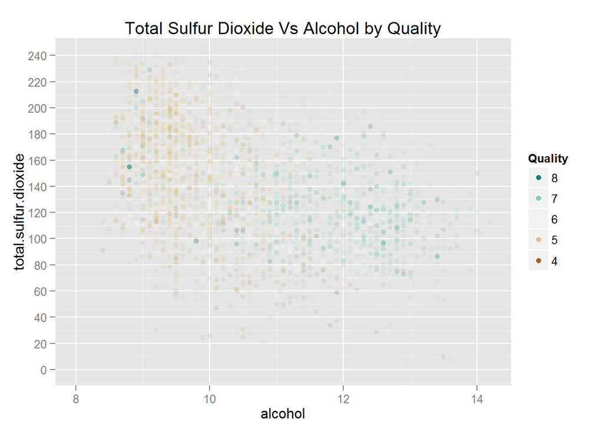

Lower alcohol and higher total sulfur dioxide area has more lower quality wines, and higher alcohol and lower total sulfur dioxide area has more higher quality wines.

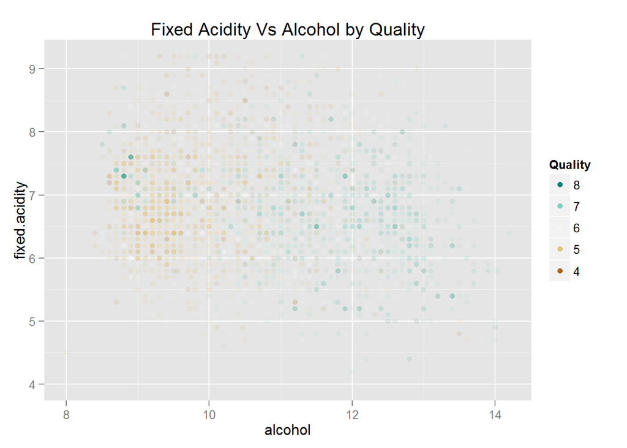

Lower alcohol and higher fixed acidity area has more lower quality wines, and higher alcohol and lower fixed acidity area has more higher quality wines.

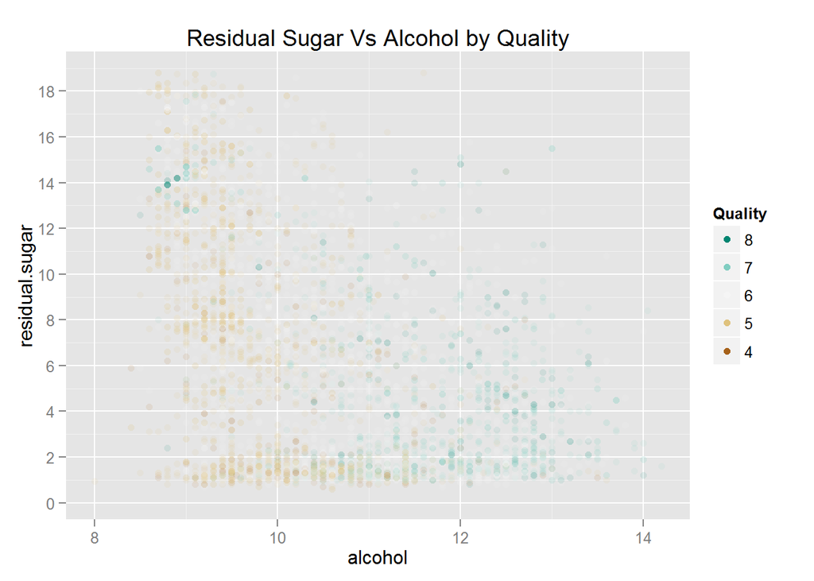

Higher alcohol and lower residual sugar area has very dense high quality wine data points. However, at lower alcohol area, lower quality wines almost evenly distributed across whole residual sugar range.

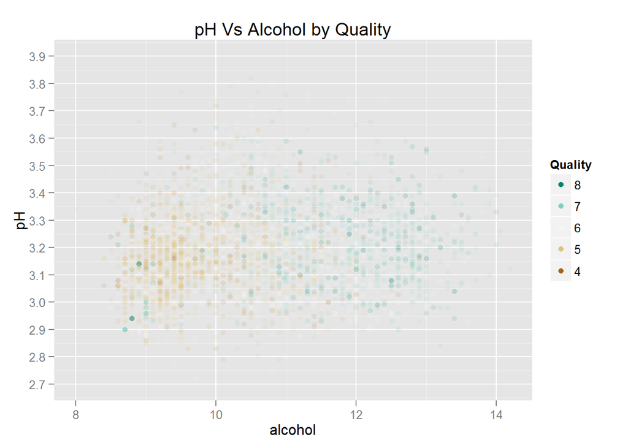

pH doesn’t have strong correlation with alcohol. And better quality wines has more dots on higher alcohol end and but almost evenly distributed within pH for each quality.

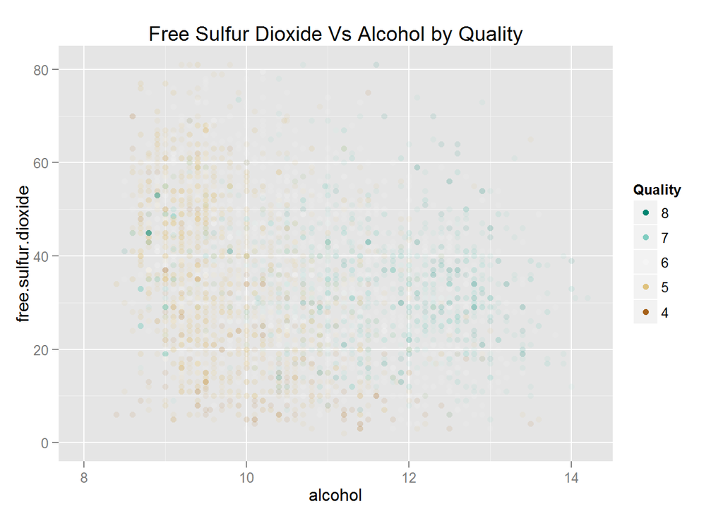

Free Sulfur Dioxide doesn’t have strong correlation with alcohol.

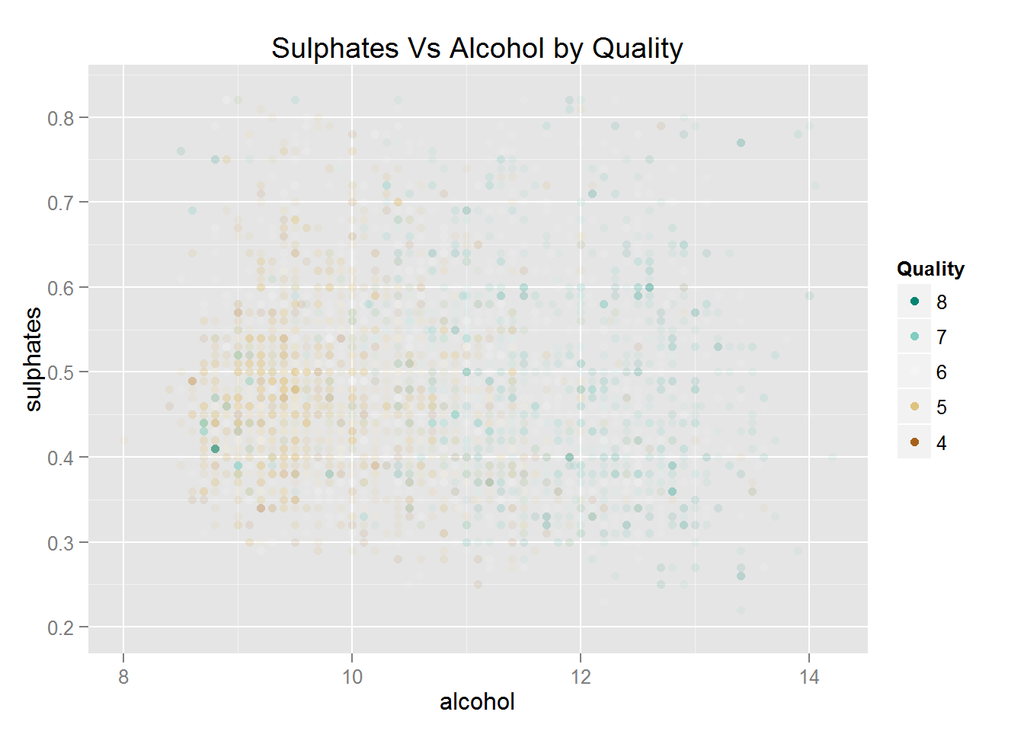

Sulphates doesn’t have strong correlation with alcohol. And it not correlated with quality.

Added new parameter total.acidity which is sum of fixed adicity, volatile acidity and citric acid.

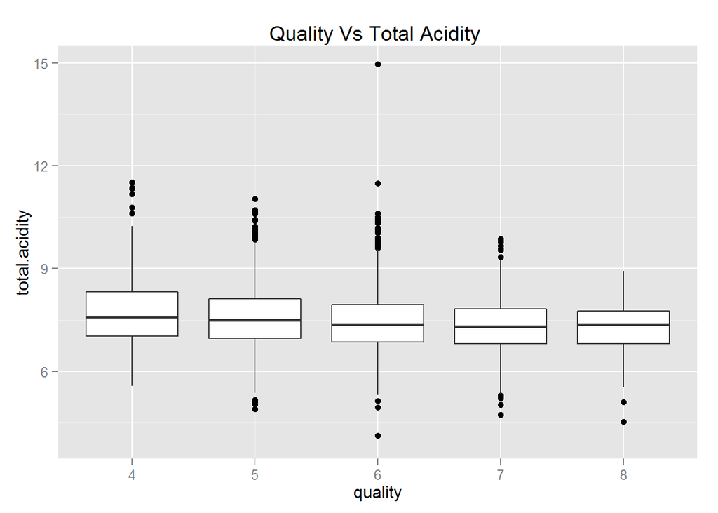

Median total acidity is very close across all wine quality.

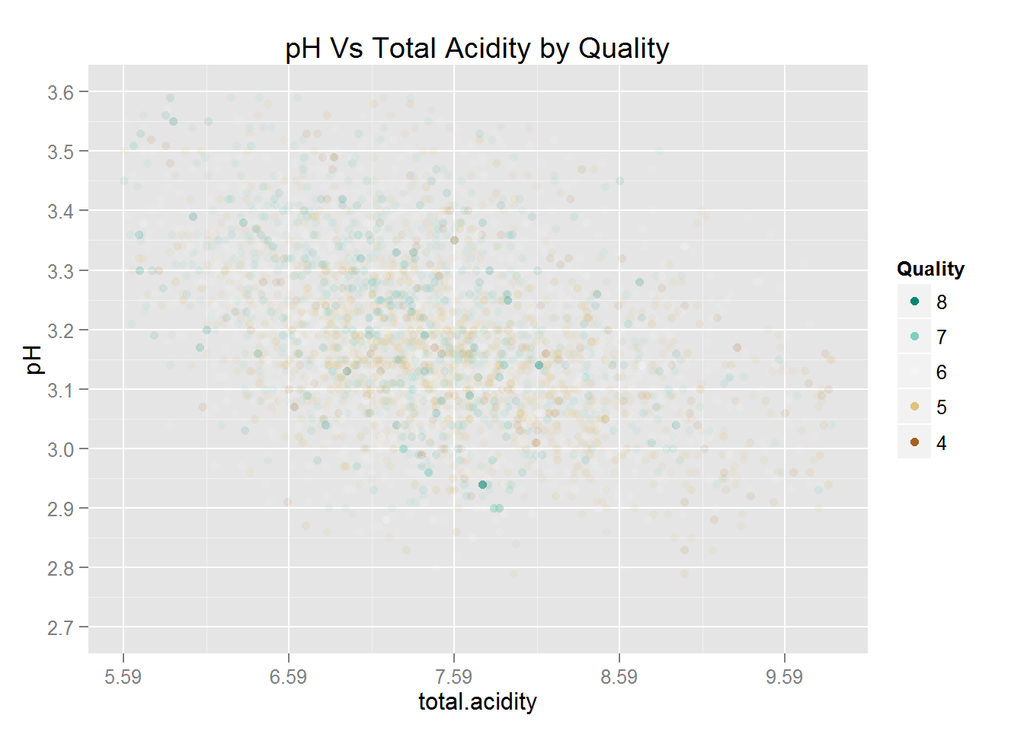

pH decreases as total acidity increases. Quality looks has no visible correlation with pH and total acidity.

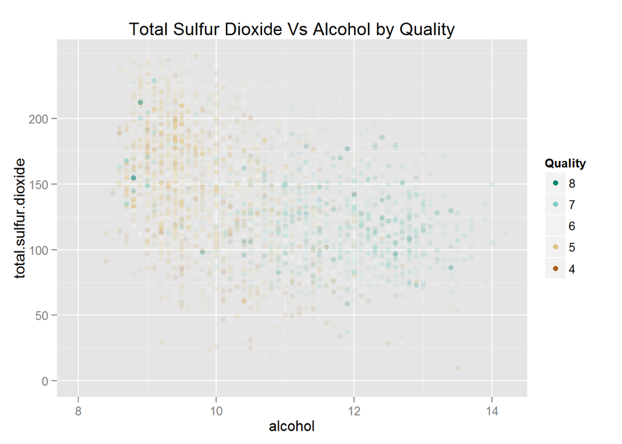

It looks like taht total sulfur dioxide decreases as alcohol increases.

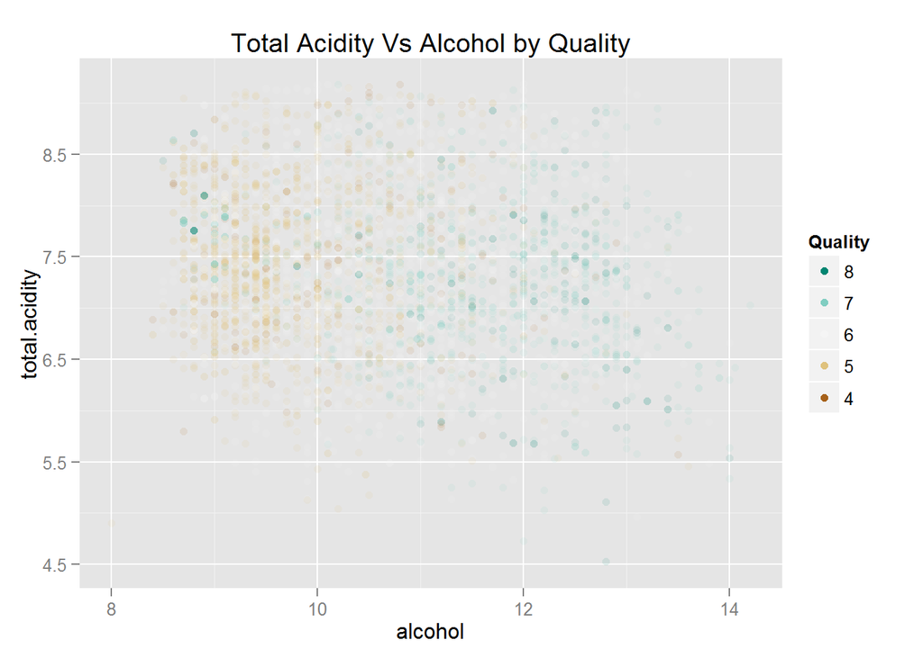

I saw similar distribution with fix acidity Vs alcohol by quality. So the new parameter total.acidity doesn’t seems add too much value in analysis here.

### Linear model

```
##
## Calls:
## m1: lm(formula = quality ~ alcohol, data = whitewines)
## m2: lm(formula = quality ~ alcohol + total.sulfur.dioxide, data = whitewines)
## m3: lm(formula = quality ~ alcohol + total.sulfur.dioxide + fixed.acidity,
##     data = whitewines)
## m4: lm(formula = quality ~ alcohol + total.sulfur.dioxide + residual.sugar,
##     data = whitewines)
##
## =============================================================
##                          m1        m2        m3        m4
## -------------------------------------------------------------
## (Intercept)            2.582***  2.419***  2.911***  2.048***
##                       (0.098)   (0.133)   (0.167)   (0.139)
## alcohol                0.313***  0.322***  0.317***  0.352***
##                       (0.009)   (0.010)   (0.010)   (0.011)
## total.sulfur.dioxide             0.001     0.001*   -0.000
##                                 (0.000)   (0.000)   (0.000)
## fixed.acidity                             -0.066***
##                                           (0.014)
## residual.sugar                                       0.022***
##                                                     (0.003)
## -------------------------------------------------------------
## R-squared                 0.190     0.190     0.194     0.202
## adj. R-squared            0.190     0.190     0.194     0.201
## sigma                     0.797     0.797     0.795     0.791
## F                      1146.395   575.100   393.081   412.870
## p                         0.000     0.000     0.000     0.000
## Log-likelihood        -5839.391 -5837.755 -5825.920 -5802.097
## Deviance               3112.257  3110.178  3095.184  3065.221
## AIC                   11684.782 11683.510 11661.839 11614.193
## BIC                   11704.272 11709.496 11694.322 11646.676
## N                      4898      4898      4898      4898
## =============================================================
```

# Multivariate Analysis

### Were there any interesting or surprising interactions between features?

I added up acid related parameter to create a new parameter total acidity. Total acidity has strong negative correction with pH, which makes sense.

I still can’t see much relationship between quality and pH, between quality and free sulfur dioxide. I thought that those two features should have strong correlation with quality when goggling chemical attribute about wines.

# Final Plots and Summary

### Plot One

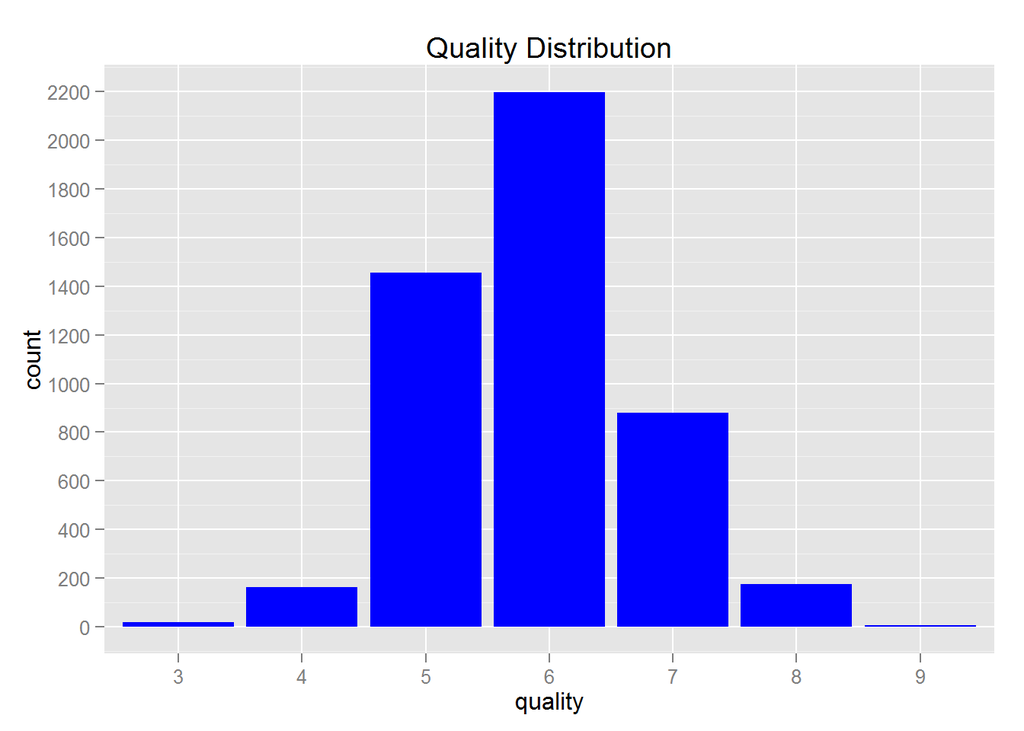